# Study *Tidy Finance with R*

Shitao

2022-08-02

# Introduction

这是[Tidy Finance with R](https://www.tidy-finance.org)的学习记录，使用的R软件版本为4.2.1（2022-06-23），下载源码[^1]可点击页面最顶端标题右侧”Code > Download Rmd”。

对内容有疑问或建议的小伙伴，欢迎在[这里](https://github.com/Shitao5/tidy-finance)提交Issues或者Pull requests，帮助完善，在下先行谢过了。🤝🤝

# 1 Introduction to Tidy Finance

说到Tidy（整洁），首先加载两个tidy开头的包：

```r
library(tidyverse)
library(tidyquant)
```

这里补充一下管道操作符`%>%`的知识，其作用是将前一步生成的结果作为下一步函数的第一个参数[^2]：

- `x %>% f()`等同于`f(x)`
- `x %>% f(y)`等同于`f(x, y)`
- `x %>% f() %>% g()`等同于`g(f(x))`
- `f(x) %>% g(y) %>% t(z)`等同于`t(g(f(x), y), z)`

是不是有点像”然后”的意思？它可以让写代码、读代码都安装从上到下、从左到右的顺序一步一步地进行，且不会生成很多的中间变量，大部分时候可以从数据到结果”一管到底”，大大增加数据分析的流畅性。快捷键为`Ctrl + Shift + M`。在4.1以上的R版本中，自带了原生的管道：`|>`，它的主要作用于`%>%`大致相同，不过`%>%`功能更丰富。

揣着这个效率神器，我们出发！🚀

## 1.1 单个股票分析

读取苹果公司股票价格数据，`tq_get()`函数默认使用雅虎数据库，因此在国内需要连接外网后使用[^3]。

```r
price <- tq_get("AAPL", # Apple Stock
                get = "stock.price",
                from = "2000-01-01",
                to = "2022-06-30")
price
```

```
#> # A tibble: 5,659 × 8
#>    symbol date        open  high   low close     volume adjusted
#>    <chr>  <date>     <dbl> <dbl> <dbl> <dbl>      <dbl>    <dbl>
#>  1 AAPL   2000-01-03 0.936 1.00  0.908 0.999  535796800    0.855
#>  2 AAPL   2000-01-04 0.967 0.988 0.903 0.915  512377600    0.782
#>  3 AAPL   2000-01-05 0.926 0.987 0.920 0.929  778321600    0.794
#>  4 AAPL   2000-01-06 0.948 0.955 0.848 0.848  767972800    0.725
#>  5 AAPL   2000-01-07 0.862 0.902 0.853 0.888  460734400    0.760
#>  6 AAPL   2000-01-10 0.911 0.913 0.846 0.873  505064000    0.746
#>  7 AAPL   2000-01-11 0.857 0.887 0.808 0.828  441548800    0.708
#>  8 AAPL   2000-01-12 0.848 0.853 0.772 0.778  976068800    0.666
#>  9 AAPL   2000-01-13 0.844 0.882 0.826 0.864 1032684800    0.739
#> 10 AAPL   2000-01-14 0.893 0.913 0.887 0.897  390376000    0.767
#> # … with 5,649 more rows
#> # ℹ Use `print(n = ...)` to see more rows
```

简单的可视化，呈现价格走势：

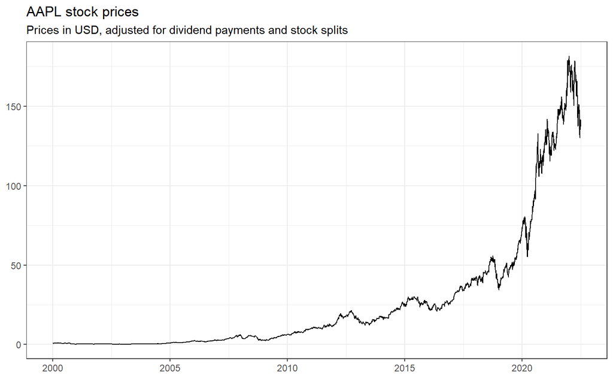

```r
price %>%
  ggplot(aes(date, adjusted)) +
  geom_line() +
  labs(x = NULL, y = NULL,
       title = "AAPL stock prices",
       subtitle = "Prices in USD, adjusted for dividend payments and stock splits")
```

根据以下公式，用调整后价格计算日收益率（Daily Return）。

$$\begin{equation}
\text{daily return} = \frac{p_t - p_{t-1}}{p_{t-1}} = \frac{p_t}{p_{t-1}} - 1
\end{equation}$$

计算前需先将数据根据日期排序，由于2000-01-03为第一天，因此计算收益率时产生缺失值(NA)，可以直接剔除。

```r
returns <- price %>%
  arrange(date) %>%
  mutate(ret = adjusted / lag(adjusted) - 1) %>%
  select(symbol, date, ret) %>%
  drop_na(ret)
returns
```

```
#> # A tibble: 5,658 × 3
#>    symbol date           ret
#>    <chr>  <date>       <dbl>
#>  1 AAPL   2000-01-04 -0.0843
#>  2 AAPL   2000-01-05  0.0146
#>  3 AAPL   2000-01-06 -0.0865
#>  4 AAPL   2000-01-07  0.0474
#>  5 AAPL   2000-01-10 -0.0176
#>  6 AAPL   2000-01-11 -0.0512
#>  7 AAPL   2000-01-12 -0.0600
#>  8 AAPL   2000-01-13  0.110
#>  9 AAPL   2000-01-14  0.0381
#> 10 AAPL   2000-01-18  0.0348
#> # … with 5,648 more rows
#> # ℹ Use `print(n = ...)` to see more rows
```

对日收益率进行汇总统计：

```r
summary(returns$ret)
```

```
#>    Min. 1st Qu.  Median    Mean 3rd Qu.    Max.
#>  -0.519  -0.010   0.001   0.001   0.013   0.139
```

可以看到最高日收益率为13.905%，最低日收益达到-51.869%，而平均日收益率为0.123%，略高于0%。

绘制日收益率柱状图，更直观地展示数据。图中的红色竖线代表日收益率的5%分位数（-0.037）[^4]。

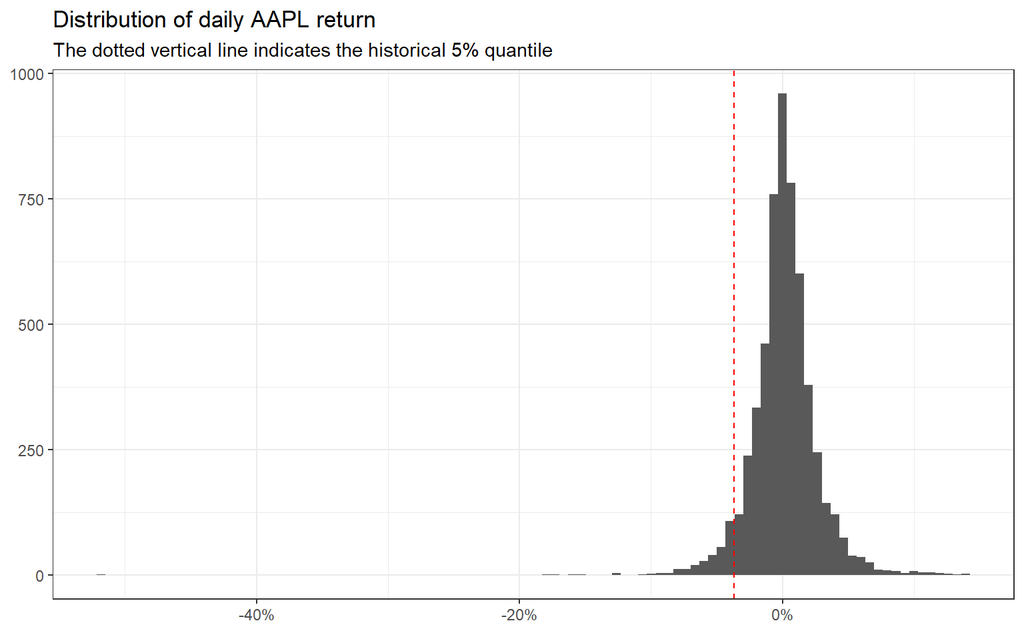

```r
quantile_05 <- quantile(returns$ret, .05)

returns %>%
  ggplot(aes(ret)) +
  geom_histogram(bins = 100) +
  geom_vline(aes(xintercept = quantile_05),
             color = "red", linetype = "dashed") +
  scale_x_continuous(labels = scales::percent) +
  labs(x = NULL, y = NULL,
       title = "Distribution of daily AAPL return",
       subtitle = "The dotted vertical line indicates the historical 5% quantile")
```

按年分组后，对日收益率进行分组统计：

```r
returns %>%
  mutate(ret = ret * 100) %>%
  group_by(year = year(date)) %>%
  summarise(across(ret,
    list(
      daily_mean = mean,
      daily_sd = sd,
      daily_min = min,
      daily_max = max
    ),
    .names = "{.fn}"
  )) %>%
  print(n = Inf)
```

```
#> # A tibble: 23 × 5
#>     year daily_mean daily_sd daily_min daily_max
#>    <dbl>      <dbl>    <dbl>     <dbl>     <dbl>
#>  1  2000   -0.346       5.49    -51.9      13.7
#>  2  2001    0.233       3.93    -17.2      12.9
#>  3  2002   -0.121       3.05    -15.0       8.46
#>  4  2003    0.186       2.34     -8.14     11.3
#>  5  2004    0.470       2.55     -5.58     13.2
#>  6  2005    0.349       2.45     -9.21      9.12
#>  7  2006    0.0949      2.43     -6.33     11.8
#>  8  2007    0.366       2.38     -7.02     10.5
#>  9  2008   -0.265       3.67    -17.9      13.9
#> 10  2009    0.382       2.14     -5.02      6.76
#> 11  2010    0.183       1.69     -4.96      7.69
#> 12  2011    0.104       1.65     -5.59      5.89
#> 13  2012    0.130       1.86     -6.44      8.87
#> 14  2013    0.0472      1.80    -12.4       5.14
#> 15  2014    0.145       1.36     -7.99      8.20
#> 16  2015    0.00199     1.68     -6.12      5.74
#> 17  2016    0.0575      1.47     -6.57      6.50
#> 18  2017    0.164       1.11     -3.88      6.10
#> 19  2018   -0.00573     1.81     -6.63      7.04
#> 20  2019    0.266       1.65     -9.96      6.83
#> 21  2020    0.281       2.94    -12.9      12.0
#> 22  2021    0.131       1.58     -4.17      5.39
#> 23  2022   -0.170       2.26     -5.64      6.98
```

## 1.2 多个股票分析

基于整洁数据(Wickham 2014)的特点，可以很方便地将单个股票的分析拓展到多个股票。接下来分析目前[道琼斯工业指数](https://en.wikipedia.org/wiki/Dow_Jones_Industrial_Average)中所有的成分股：

```r
ticker <- tq_index("DOW") # 获取成分股信息
ticker
```

```
#> # A tibble: 30 × 8
#>    symbol company                    ident…¹ sedol weight sector share…² local…³
#>    <chr>  <chr>                      <chr>   <chr>  <dbl> <chr>    <dbl> <chr>
#>  1 UNH    UnitedHealth Group Incorp… 91324P… 2917… 0.110  Healt… 5706213 USD
#>  2 GS     Goldman Sachs Group Inc.   38141G… 2407… 0.0667 Finan… 5706213 USD
#>  3 HD     Home Depot Inc.            437076… 2434… 0.0607 Consu… 5706213 USD
#>  4 MSFT   Microsoft Corporation      594918… 2588… 0.0560 Infor… 5706213 USD
#>  5 MCD    McDonald's Corporation     580135… 2550… 0.0534 Consu… 5706213 USD
#>  6 AMGN   Amgen Inc.                 031162… 2023… 0.0506 Healt… 5706213 USD
#>  7 V      Visa Inc. Class A          92826C… B2PZ… 0.0428 Infor… 5706213 USD
#>  8 HON    Honeywell International I… 438516… 2020… 0.0386 Indus… 5706213 USD
#>  9 CAT    Caterpillar Inc.           149123… 2180… 0.0381 Indus… 5706213 USD
#> 10 CRM    Salesforce Inc.            79466L… 2310… 0.0367 Infor… 5706213 USD
#> # … with 20 more rows, and abbreviated variable names ¹identifier,
#> #   ²shares_held, ³local_currency
#> # ℹ Use `print(n = ...)` to see more rows
```

获取所有成分股在2000-01-01到2022-06-30的股票信息：

```r
index_prices <- tq_get(ticker,
                       get = "stock.prices",
                       from = "2000-01-01",
                       to = "2022-06-30")
index_prices
```

```
#> # A tibble: 161,753 × 15
#>    symbol company   ident…¹ sedol weight sector share…² local…³ date        open
#>    <chr>  <chr>     <chr>   <chr>  <dbl> <chr>    <dbl> <chr>   <date>     <dbl>
#>  1 UNH    UnitedHe… 91324P… 2917…  0.110 Healt… 5706213 USD     2000-01-03  6.64
#>  2 UNH    UnitedHe… 91324P… 2917…  0.110 Healt… 5706213 USD     2000-01-04  6.67
#>  3 UNH    UnitedHe… 91324P… 2917…  0.110 Healt… 5706213 USD     2000-01-05  6.64
#>  4 UNH    UnitedHe… 91324P… 2917…  0.110 Healt… 5706213 USD     2000-01-06  6.62
#>  5 UNH    UnitedHe… 91324P… 2917…  0.110 Healt… 5706213 USD     2000-01-07  7.19
#>  6 UNH    UnitedHe… 91324P… 2917…  0.110 Healt… 5706213 USD     2000-01-10  7.73
#>  7 UNH    UnitedHe… 91324P… 2917…  0.110 Healt… 5706213 USD     2000-01-11  7.38
#>  8 UNH    UnitedHe… 91324P… 2917…  0.110 Healt… 5706213 USD     2000-01-12  7.48
#>  9 UNH    UnitedHe… 91324P… 2917…  0.110 Healt… 5706213 USD     2000-01-13  7.52
#> 10 UNH    UnitedHe… 91324P… 2917…  0.110 Healt… 5706213 USD     2000-01-14  7.75
#> # … with 161,743 more rows, 5 more variables: high <dbl>, low <dbl>,
#> #   close <dbl>, volume <dbl>, adjusted <dbl>, and abbreviated variable names
#> #   ¹identifier, ²shares_held, ³local_currency
#> # ℹ Use `print(n = ...)` to see more rows, and `colnames()` to see all variable names
```

共获得了来自30家公司的161753行数据，对调整价格进行可视化，查看总体走势：

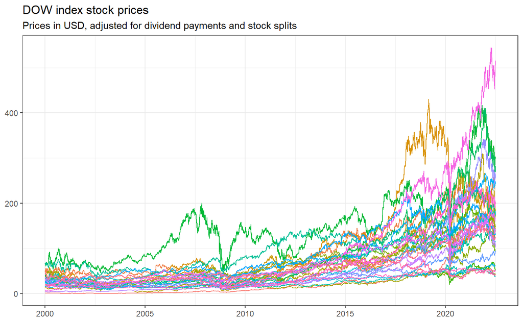

```r
index_prices %>%
  ggplot(aes(date, adjusted, color = symbol)) +
  geom_line() +
  labs(x = NULL, y = NULL, color = NULL,
       title = "DOW index stock prices",
       subtitle = "Prices in USD, adjusted for dividend payments and stock splits") +
  theme(legend.position = "none")
```

对30家公司的日收益率进行汇总统计：

```r
all_returns <- index_prices %>%
  group_by(symbol) %>%
  mutate(ret = adjusted / lag(adjusted) - 1) %>%
  select(symbol, date, ret) %>%
  drop_na(ret) %>%
  ungroup()  # 解除分组

all_returns %>%
  mutate(ret = ret * 100) %>%
  group_by(symbol) %>%
  summarise(across(
    ret,
    list(
      daily_mean = mean,
      daily_sd = sd,
      daily_min = min,
      daily_max = max
    ),
    .names = "{.fn}"
  ))
```

```
#> # A tibble: 30 × 5
#>    symbol daily_mean daily_sd daily_min daily_max
#>    <chr>       <dbl>    <dbl>     <dbl>     <dbl>
#>  1 AAPL       0.123      2.52     -51.9      13.9
#>  2 AMGN       0.0483     1.98     -13.4      15.1
#>  3 AXP        0.0514     2.30     -17.6      21.9
#>  4 BA         0.0544     2.23     -23.8      24.3
#>  5 CAT        0.0670     2.04     -14.5      14.7
#>  6 CRM        0.117      2.69     -27.1      26.0
#>  7 CSCO       0.0300     2.39     -16.2      24.4
#>  8 CVX        0.0523     1.76     -22.1      22.7
#>  9 DIS        0.0437     1.93     -18.4      16.0
#> 10 DOW        0.0625     2.69     -21.7      20.9
#> # … with 20 more rows
#> # ℹ Use `print(n = ...)` to see more rows
```

到此为止，就可以下载和处理任意股票组合的价格数据了。比如用`ticker <- tq_index("SP500")`修改`ticker`为标普500的成分股信息，就可以分析标普500中股票价格数据。因为有很多数据需要下载，这个操作比较耗时，这里不演示。

## 1.3 其他数据汇总形式

道琼斯总交易量：

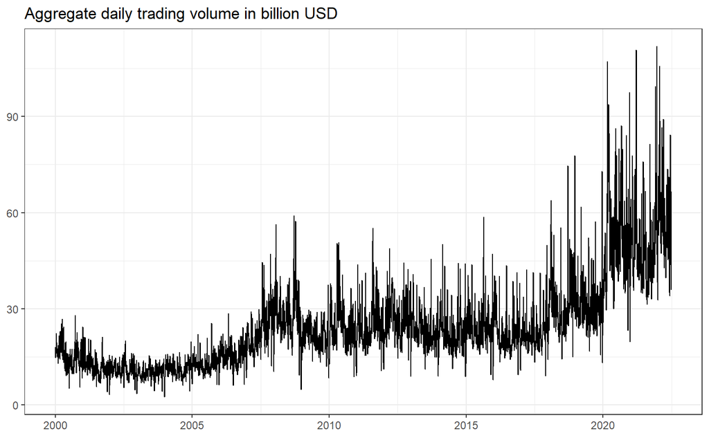

```r
volume <- index_prices %>%
  mutate(volume_usd = volume * close / 1e9) %>%
  group_by(date) %>%
  summarise(volume = sum(volume_usd))

volume %>%
  ggplot(aes(date, volume)) +
  geom_line() +
  labs(x = NULL, y = NULL,
       title = "Aggregate daily trading volume in billion USD")
```

可利用45°线比较第$t$天与第$t-1$天的交易量：

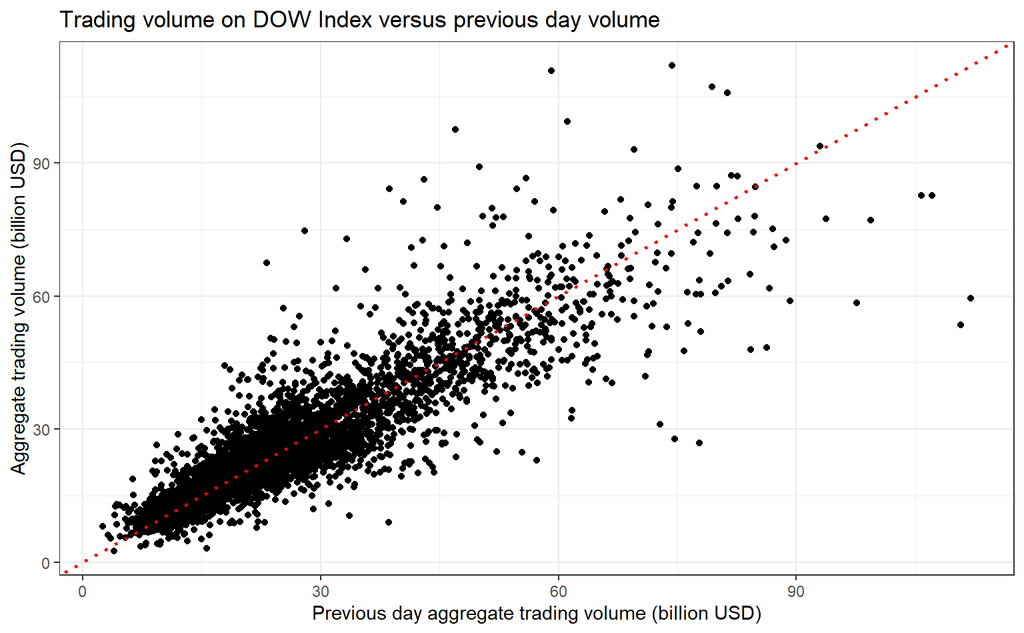

```r
volume %>%
  ggplot(aes(lag(volume), volume)) +
  geom_point() +
  geom_abline(aes(intercept = 0, slope = 1),
              linetype = "dotted", color = "red",
              size = .8) +
  labs(x = "Previous day aggregate trading volume (billion USD)",
       y = "Aggregate trading volume (billion USD)",
       title = "Trading volume on DOW Index versus previous day volume")
```

纯纯目测可以发现：交易量大的日子后面往往也是交易量大的日子。

## 1.4 投资组合问题

最佳投资组合追求高回报、低风险：

> The standard framework for optimal portfolio selection considers investors that prefer higher future returns but dislike future return volatility (defined as the square root of the return variance): the *mean-variance investor*.

```r
# 清洗掉行数较少的企业的所有股票
index_prices <- index_prices %>%
  group_by(symbol) %>%
  mutate(n = n()) %>%
  ungroup() %>%
  filter(n == max(n)) %>%
  select(-n)

# 计算每个企业每月的回报率
returns <- index_prices %>%
  mutate(month = floor_date(date, "month")) %>%
  group_by(symbol, month) %>%
  summarise(price = last(adjusted), .groups = "drop_last") %>%
  mutate(ret = price / lag(price) - 1) %>%
  drop_na(ret) %>%
  select(-price)
```

将收益率转为$(T \times N)$的矩阵，计算样本回报率均值矩阵$\hat{\mu}$和样本协方差矩阵$\hat{\Sigma}$:
$$\hat\mu = \frac{1}{T}\sum\limits_{t=1}^T r_t$$
$$\hat\Sigma = \frac{1}{T-1}\sum\limits_{t=1}^T (r_t - \hat\mu)(r_t - \hat\mu)'$$

```r
return_matrix <- returns %>%
  pivot_wider(names_from = symbol,
              values_from = ret) %>%
  select(-month)

mu <- colMeans(return_matrix)
Sigma <- cov(return_matrix)
```

#### 难点警告

下面的内容理解还不透彻，先记录。

接下来计算最小方差的投资组合权重$\omega_\text{mvp}$和它的预期收益$\omega_\text{mvp}'\mu$和波动率$\sqrt{\omega_\text{mvp}'\Sigma\omega_\text{mvp}}$。$\omega_\text{mvp}$是以下问题的解：
$$\omega_\text{mvp} = \arg\min w'\Sigma w \\
\text{ s.t. } \sum\limits_{i=1}^Nw_i = 1$$

```r
N <- ncol(return_matrix)
iota <- rep(1, N)
mvp_weights <- solve(Sigma) %*% iota  # solve用于求逆
mvp_weights <- mvp_weights / sum(mvp_weights)

tibble(
  expected_ret = t(mvp_weights) %*% mu,
  volatility = sqrt(t(mvp_weights) %*% Sigma %*% mvp_weights)
)
```

```
#> # A tibble: 1 × 2
#>   expected_ret[,1] volatility[,1]
#>              <dbl>          <dbl>
#> 1          0.00801         0.0314
```

尝试寻找一个可以获得三倍于最小方差组合的预期收益的投资组合权重：

```r
mu_bar <- 3 * t(mvp_weights) %*% mu

C <- as.numeric(t(iota) %*% solve(Sigma) %*% iota)
D <- as.numeric(t(iota) %*% solve(Sigma) %*% mu)
E <- as.numeric(t(mu) %*% solve(Sigma) %*% mu)

lambda_tilde <- as.numeric(2 * (mu_bar - D / C) / (E - D^2 / C))
efp_weights <- mvp_weights +
  lambda_tilde / 2 * (solve(Sigma) %*% mu - D * mvp_weights)
```

## 1.5 有效边界

只要有两个有效的投资组合，就可以通过它们权重的线性组合得到有效边界。有效边界描述了在每个风险水平下可以实现的最高预期收益。

```r
c <- seq(from = -.4, to = 1.9, by = .01)
res <- tibble(
  c = c,
  mu = NA,
  sd = NA
)

for (i in seq_along(c)) {
  w <- (1 - c[i]) * mvp_weights + (c[i]) * efp_weights
  res$mu[i] <- 12 * 100 * t(w) %*% mu
  res$sd[i] <- 12 * sqrt(100) * sqrt(t(w) %*% Sigma %*% w)
}
```

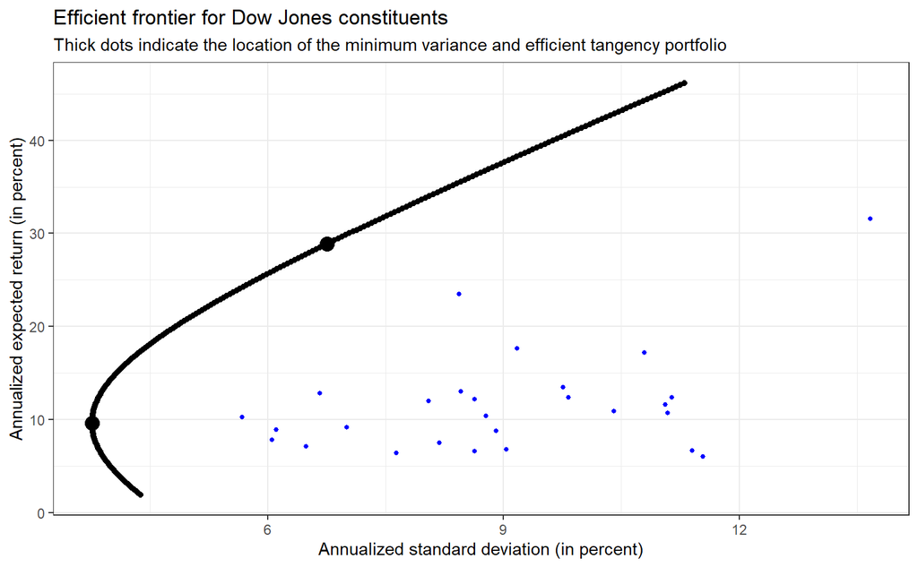

```r
res %>%
  ggplot(aes(sd, mu)) +
  geom_point() +
  geom_point(
    data = res %>% filter(c %in% c(0, 1)),
    size = 4
  ) +
  geom_point(
    data = tibble(
      mu = 12 * 100 * mu,
      sd = 12 * 10 * sqrt(diag(Sigma))
    ),
    aes(sd, mu), size = 1, color = "blue"
  ) +
  labs(
    x = "Annualized standard deviation (in percent)",
    y = "Annualized expected return (in percent)",
    title = "Efficient frontier for Dow Jones constituents",
    subtitle = "Thick dots indicate the location of the minimum variance and efficient tangency portfolio"
    )
```

# 2 访问和处理金融数据

## 2.1 Fama-French data

```r
library(lubridate)
library(scales)
library(frenchdata)
```

定义获取和储存的金融数据的起止日期，方便未来更新：

```r
start_date <- ymd("1960-01-01")
end_date <- ymd("2020-12-31")
```

`frenchdata`包提供了从[Prof. Kenneth French](https://mba.tuck.dartmouth.edu/pages/faculty/ken.french/data_library.html)金融数据库下载和读取数据集的功能。

```r
# 月度数据
factors_ff_monthly_raw <- download_french_data("Fama/French 3 Factors")
factors_ff_monthly <- factors_ff_monthly_raw$subsets$data[[1]] %>%
  transmute(
    month = floor_date(ymd(str_c(date, "01")), "month"),
    rf = as.numeric(RF) / 100,
    mkt_excess = as.numeric(`Mkt-RF`) / 100,
    smb = as.numeric(SMB) / 100,
    hml = as.numeric(HML) / 100
  ) %>%
  filter(month >= start_date & month <= end_date)

# 每日数据
factors_ff_daily_raw <- download_french_data("Fama/French 3 Factors [Daily]")
factors_ff_daily <- factors_ff_daily_raw$subsets$data[[1]] |>
  transmute(
    date = ymd(date),
    rf = as.numeric(RF) / 100,
    mkt_excess = as.numeric(`Mkt-RF`) / 100,
    smb = as.numeric(SMB) / 100,
    hml = as.numeric(HML) / 100
  ) |>
  filter(date >= start_date & date <= end_date)

industries_ff_monthly_raw <- download_french_data("10 Industry Portfolios")
industries_ff_monthly <- industries_ff_monthly_raw$subsets$data[[1]] |>
  mutate(month = floor_date(ymd(str_c(date, "01")), "month")) |>
  mutate(across(where(is.numeric), ~ . / 100)) |>
  select(month, everything(), -date) |>
  filter(month >= start_date & month <= end_date)
```

可以用`get_french_data_list()`查看Kenneth French主页上的投资组合汇报时间序列数据。

## 2.2 q-facrors

```r
factors_q_monthly_link <-
  "http://global-q.org/uploads/1/2/2/6/122679606/q5_factors_monthly_2020.csv"
factors_q_monthly <- read_csv(factors_q_monthly_link) |>
  mutate(month = ymd(str_c(year, month, "01", sep = "-"))) |>
  select(-R_F, -R_MKT, -year) |>
  rename_with(~ str_remove(., "R_")) |>
  rename_with(~ str_to_lower(.)) |>
  mutate(across(-month, ~ . / 100)) |>
  filter(month >= start_date & month <= end_date)
```

## 2.3 宏观经济预测因素

```r
library(readxl)
library(googledrive)
```

`googledrive`包用于连接谷歌硬盘。通常需要认证后才能用R与谷歌硬盘交互，而读取公共链接存储的数据，无需认证。

```r
drive_deauth()
macro_predictors_link <-
  "https://drive.google.com/file/d/1ACbhdnIy0VbCWgsnXkjcddiV8HF4feWv/view"
drive_download(
  macro_predictors_link,
  path = "data/macro_predictors.xlsx"
  )
```

```
#> File downloaded:
#> • 'PredictorData2020.xlsx' <id: 1ACbhdnIy0VbCWgsnXkjcddiV8HF4feWv>
#> Saved locally as:
#> • 'data/macro_predictors.xlsx'
```

数据被放置在了当前工作目录下的data文件夹[^5]。使用`readxl`包进行读取：

```r
macro_predictors <- read_xlsx("data/macro_predictors.xlsx",
  sheet = "Monthly"
) %>%
  mutate(month = ym(yyyymm)) %>%
  filter(month >= start_date & month <= end_date) %>%
  mutate(across(where(is.character), as.numeric)) %>%
  mutate(
    IndexDiv = Index + D12,
    logret = log(IndexDiv) - log(lag(IndexDiv)),
    Rfree = log(Rfree + 1),
    rp_div = lead(logret - Rfree, 1), # Future excess market return
    dp = log(D12) - log(Index), # Dividend Price ratio
    dy = log(D12) - log(lag(Index)), # Dividend yield
    ep = log(E12) - log(Index), # Earnings price ratio
    de = log(D12) - log(E12), # Dividend payout ratio
    tms = lty - tbl, # Term spread
    dfy = BAA - AAA # Default yield spread
  ) %>%
  select(month, rp_div, dp, dy, ep, de, svar,
    bm = `b/m`, ntis, tbl, lty, ltr,
    tms, dfy, infl
  ) %>%
  drop_na()
```

读取数据至内存后，可以删除下载下来的文件：

```r
file.remove("data/macro_predictors.xlsx")
```

```
#> [1] TRUE
```

## 2.4 其他宏观经济数据

利用`tidyquant`包从圣路易斯联邦储备银行提供的联邦储备经济数据（FRED）中下载数据，例如下载CPI数据：

```r
cpi_monthly <- tq_get("CPIAUCNS",
       get = "economic.data",
       from = start_date,
       to = end_date)
```

# References

Wickham, Hadley. 2014. “Tidy Data.” *Journal of Statistical Software* 59 (10). https://doi.org/10.18637/jss.v059.i10.

[^1]: 在安装后所需的包后，运行源码可生成该文件的文本内容。由于配置了css等样式文件，如果需要完全重现该文件，请在[Github](https://github.com/Shitao5/tidy-finance)下载该仓库后进行Knit。
[^2]: 也可以不是第一个，这里先按下不表。
[^3]: 或者使用[RStudio Cloud](https://rstudio.cloud)运行代码。
[^4]: 5%分位数与风险价值密切相关，也是监管机构通常监控的风险评估。
[^5]: 笔记采用项目进行管理，因此所有本地文件均为相对路径，方便项目迁移。

# ㊙️未完待续㊙️

客官，已经到底啦，小的争取每天更新噢😉